# Data Wrangling and Analysis in R

## 1. Installing packages

In R, packages are a collection of functions that provide functinalities not given by the R core functionalities. We’ll install tidyverse packages which will provide us with packages for performing data manipulation and analysis.

#### Let’s install tidyverse packages in Rstudio

```r
install.packages("tidyverse")
install.packages("readr")
install.packages("extrafont")
```

#### Load tidyverse for use in our notebook

```r
library(tidyverse)
library(readr)
library(extrafont)
loadfonts(device = "win")
```

## 2. Load dataset

MTN Telecom offers mobile and internet services to its customers. These services include phone, multiple lines, internet, online security, online backup, device protection, tech support, and streaming TV and movies.

You have been provided with the current customer data. Since you will be working towards a descriptive report than a predictive one, you decide to think critically of the kind of questions that would help you craft customer retention programs. You then later use the given data set to answer your questions but before you start, you reading, explore, clean and visualise your dataset.

```r
# Import, Load dataset and preview its summarized information.

MTN_df <- read_csv("https://bit.ly/2ZlpzjF")
head(MTN_df)
```

| customerID | GENDER | SeniorCitizen | PARTNER | Dependents | tenure | PhoneService | MultipleLines | InternetService | OnlineSecurity | OnlineBackup | DeviceProtection | TECHSUPPORT | StreamingTV | StreamingMovies | Contract | PaperlessBilling | PaymentMethod | MonthlyCharges | TotalCharges | Churn |
| --- | --- | --- | --- | --- | --- | --- | --- | --- | --- | --- | --- | --- | --- | --- | --- | --- | --- | --- | --- | --- |
| 7590-VHVEG | Female | 0 | Yes | No | 1 | No | No phone service | DSL | No | Yes | No | No | No | No | Month-to-month | Yes | Electronic check | 29.85 | 29.85 | No |
| 5575-GNVDE | Male | 0 | No | No | 34 | Yes | No | DSL | Yes | No | Yes | No | No | No | One year | No | Mailed check | 56.95 | 1889.50 | No |
| 3668-QPYBK | Male | 0 | No | No | 2 | Yes | No | DSL | Yes | Yes | No | No | No | No | Month-to-month | Yes | Mailed check | 53.85 | 108.15 | Yes |
| 7795-CFOCW | Male | 0 | No | No | 45 | No | No phone service | DSL | Yes | No | Yes | Yes | No | No | One year | No | Bank transfer (automatic) | 42.30 | 1840.75 | No |
| 9237-HQITU | Female | 0 | No | No | 2 | Yes | No | Fiber optic | No | No | No | No | No | No | Month-to-month | Yes | Electronic check | 70.70 | 151.65 | Yes |
| 9305-CDSKC | Female | 0 | No | No | 8 | Yes | Yes | Fiber optic | No | No | Yes | No | Yes | Yes | Month-to-month | Yes | Electronic check | 99.65 | 820.50 | Yes |

```r
#check the no of rows and cols
dim(MTN_df)
```

```
## [1] 7050   21
```

## 3. Data cleaning

### Data understanding

```r
# Step1: get column names and perform standardisation
names(MTN_df)
```

```
##  [1] "customerID"       "GENDER"           "SeniorCitizen"    "PARTNER"
##  [5] "Dependents"       "tenure"           "PhoneService"     "MultipleLines"
##  [9] "InternetService"  "OnlineSecurity"   "OnlineBackup"     "DeviceProtection"
## [13] "TECHSUPPORT"      "StreamingTV"      "StreamingMovies"  "Contract"
## [17] "PaperlessBilling" "PaymentMethod"    "MonthlyCharges"   "TotalCharges"
## [21] "Churn"
```

```r
#Step 2: convert all column names to lower case
names(MTN_df) <- tolower(names(MTN_df))
names(MTN_df)
```

```
##  [1] "customerid"       "gender"           "seniorcitizen"    "partner"
##  [5] "dependents"       "tenure"           "phoneservice"     "multiplelines"
##  [9] "internetservice"  "onlinesecurity"   "onlinebackup"     "deviceprotection"
## [13] "techsupport"      "streamingtv"      "streamingmovies"  "contract"
## [17] "paperlessbilling" "paymentmethod"    "monthlycharges"   "totalcharges"
## [21] "churn"
```

```r
#Step3: Remove all leading and trailing spaces
names(MTN_df) <- trimws(names(MTN_df), which = c("both"))
names(MTN_df)
```

```
##  [1] "customerid"       "gender"           "seniorcitizen"    "partner"
##  [5] "dependents"       "tenure"           "phoneservice"     "multiplelines"
##  [9] "internetservice"  "onlinesecurity"   "onlinebackup"     "deviceprotection"
## [13] "techsupport"      "streamingtv"      "streamingmovies"  "contract"
## [17] "paperlessbilling" "paymentmethod"    "monthlycharges"   "totalcharges"
## [21] "churn"
```

### Removing Irrelevant data

```r
#check for duplicates
MTN_df[duplicated(MTN_df), ]
```

| customerid | gender | seniorcitizen | partner | dependents | tenure | phoneservice | multiplelines | internetservice | onlinesecurity | onlinebackup | deviceprotection | techsupport | streamingtv | streamingmovies | contract | paperlessbilling | paymentmethod | monthlycharges | totalcharges | churn |
| --- | --- | --- | --- | --- | --- | --- | --- | --- | --- | --- | --- | --- | --- | --- | --- | --- | --- | --- | --- | --- |
| 6876-ADESB | Male | 0 | No | Yes | 1 | Yes | No | DSL | No | No | Yes | No | No | No | Month-to-month | No | Electronic check | 48.95 | 48.95 | Yes |
| 1427-VERSM | Female | 0 | Yes | No | 56 | Yes | No | Fiber optic | No | No | Yes | Yes | Yes | Yes | Month-to-month | Yes | Electronic check | 98.70 | 5669.50 | No |
| 3967-KXAPS | Male | 0 | Yes | No | 72 | Yes | Yes | DSL | Yes | Yes | Yes | Yes | Yes | Yes | Two year | No | Credit card (automatic) | 92.30 | 6719.90 | No |
| 3967-KXAPS | Male | 0 | Yes | No | 72 | Yes | Yes | DSL | Yes | Yes | Yes | Yes | Yes | Yes | Two year | No | Credit card (automatic) | 92.30 | 6719.90 | No |
| 2314-TNDJQ | Female | 0 | Yes | Yes | 72 | No | No phone service | DSL | Yes | Yes | Yes | Yes | No | Yes | Two year | No | Credit card (automatic) | 55.65 | 3880.05 | No |
| 2314-TNDJQ | Female | 0 | Yes | Yes | 72 | No | No phone service | DSL | Yes | Yes | Yes | Yes | No | Yes | Two year | No | Credit card (automatic) | 55.65 | 3880.05 | No |
| 4501-VCPFK | Male | 0 | No | No | 26 | No | No phone service | DSL | No | No | Yes | Yes | No | No | Month-to-month | No | Electronic check | 35.75 | 1022.50 | No |

```r
#remove duplicates from the dataframe
MTN_df <- unique(MTN_df)

#confirm all duplicates are removed
MTN_df[duplicated(MTN_df), ]
```

| customerid | gender | seniorcitizen | partner | dependents | tenure | phoneservice | multiplelines | internetservice | onlinesecurity | onlinebackup | deviceprotection | techsupport | streamingtv | streamingmovies | contract | paperlessbilling | paymentmethod | monthlycharges | totalcharges | churn |
| --- | --- | --- | --- | --- | --- | --- | --- | --- | --- | --- | --- | --- | --- | --- | --- | --- | --- | --- | --- | --- |

### handle missing data

```r
#check if there is missing data from the df
colSums(is.na(MTN_df))
```

```
##       customerid           gender    seniorcitizen          partner
##                0                1                3               12
##       dependents           tenure     phoneservice    multiplelines
##               10               11               15               17
##  internetservice   onlinesecurity     onlinebackup deviceprotection
##               16               16               15               14
##      techsupport      streamingtv  streamingmovies         contract
##               13               13               12               12
## paperlessbilling    paymentmethod   monthlycharges     totalcharges
##               12               12               12               23
##            churn
##               12
```

```r
#Remove all records with missing data
clean_df <- na.omit(MTN_df)

#confirm no missing values
colSums(is.na(clean_df))
```

```
##       customerid           gender    seniorcitizen          partner
##                0                0                0                0
##       dependents           tenure     phoneservice    multiplelines
##                0                0                0                0
##  internetservice   onlinesecurity     onlinebackup deviceprotection
##                0                0                0                0
##      techsupport      streamingtv  streamingmovies         contract
##                0                0                0                0
## paperlessbilling    paymentmethod   monthlycharges     totalcharges
##                0                0                0                0
##            churn
##                0
```

```r
unique(clean_df$seniorcitizen)
```

```
## [1] 0 1
```

```r
# column senior_citizen should be a boolean
clean_df$seniorcitizen[clean_df$seniorcitizen == 0] <- 'No'
clean_df$seniorcitizen[clean_df$seniorcitizen == 1] <- 'Yes'

#Check unique values
unique(clean_df$seniorcitizen)
```

```
## [1] "No"  "Yes"
```

```r
#resolving the issues in the 'paymentmethod' variable

# - Replace 'Mailed checkkk' with 'Mailed check',
clean_df$paymentmethod[clean_df$paymentmethod == "Mailed checkkk"] <- "Mailed check"

# - Replace 'Electronic checkk', 'Electronic check'
clean_df$paymentmethod[clean_df$paymentmethod == "Electronic checkk"] <- "Electronic check"

#confirm all replacements have been done
unique(clean_df$paymentmethod)
```

```
## [1] "Electronic check"          "Mailed check"
## [3] "Bank transfer (automatic)" "Credit card (automatic)"
```

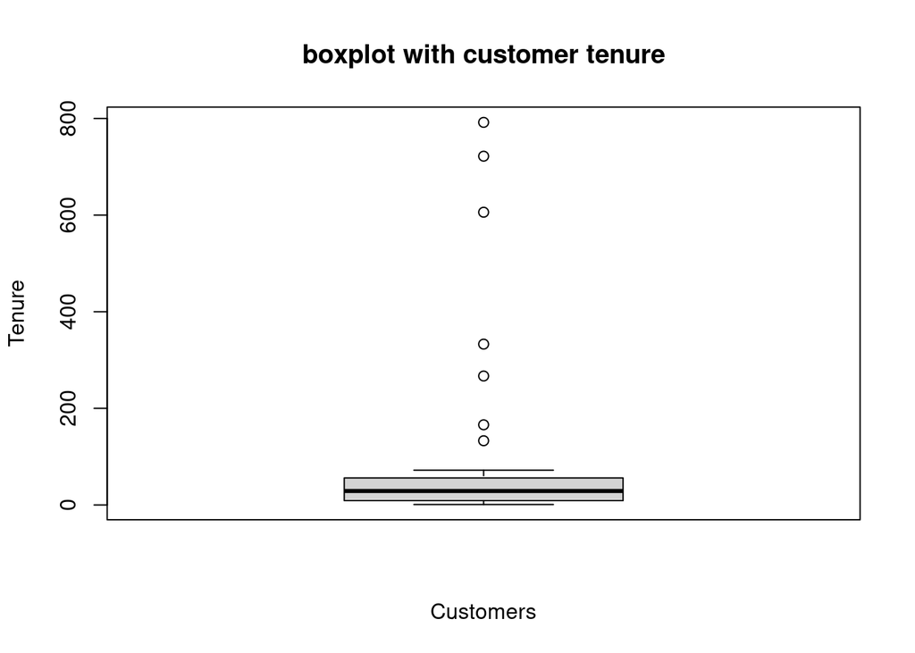

```r
# visual distribution of the outliers using a box plot

#prepare data
tenure <- clean_df$tenure
monthly_charge <- clean_df$monthlycharges
Total_charge <- clean_df$totalcharges


#plot the chart
boxplot(tenure,
        names = "tenure",
        xlab = "Customers",
        ylab = "Tenure",
        main = "boxplot with customer tenure")
```

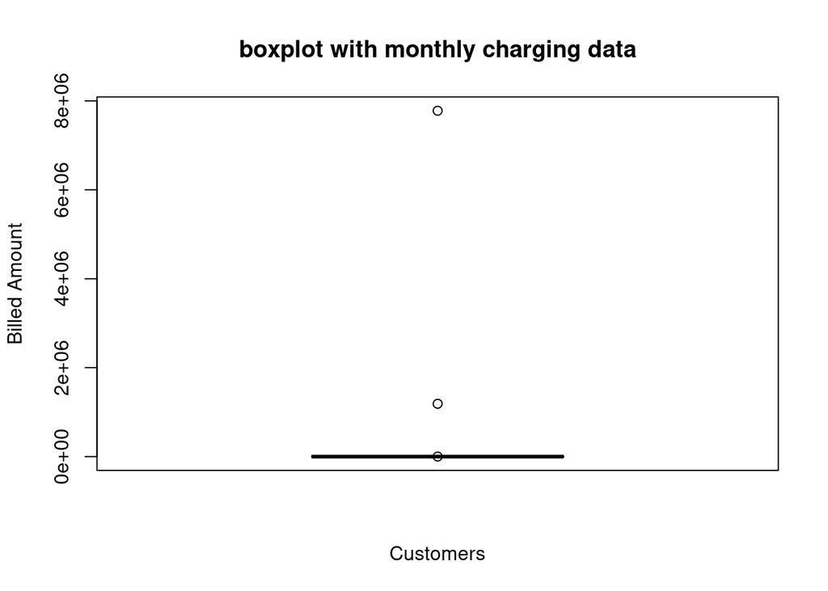

```r
boxplot(monthly_charge,
        names = "monthly",
        xlab = "Customers",
        ylab = "Billed Amount",
        main = "boxplot with monthly charging data")
```

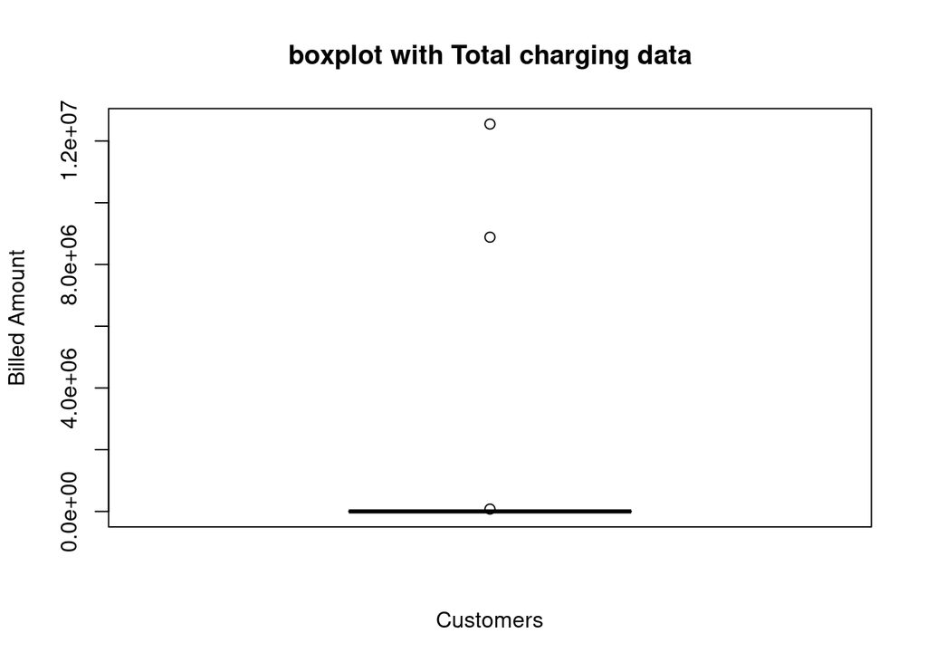

```r
boxplot(Total_charge,
        names = "Total",
        xlab = "Customers",
        ylab = "Billed Amount",
        main = "boxplot with Total charging data")
```

### Dealing with outliers

```r
#Removing the outliers using IQR method
dim(clean_df)
```

```
## [1] 7003   21
```

```r
#calculate lower and upper percentiles
lower_bound <- quantile(clean_df$tenure, 0.025)
upper_bound <- quantile(clean_df$tenure, 0.975)
lower_bound
```

```
## 2.5%
##    1
```

```r
upper_bound
```

```
## 97.5%
##    72
```

```r
#getting values that are not outliers
tenure_not_outlier_values <- which(clean_df$tenure > lower_bound & clean_df$tenure < upper_bound)

IQR_df<- clean_df[tenure_not_outlier_values,]

dim(IQR_df)
```

```
## [1] 6024   21
```

```r
lower_bound <- quantile(IQR_df$monthlycharges, 0.025)
upper_bound <- quantile(IQR_df$monthlycharges, 0.975)
lower_bound
```

```
##  2.5%
## 19.45
```

```r
upper_bound
```

```
## 97.5%
##   110
```

```r
#getting values that are not outliers
not_outlier_values <- which(IQR_df$monthlycharges > lower_bound & IQR_df$monthlycharges < upper_bound)

IQR2_df<- IQR_df[not_outlier_values, ]

#check values after removing outliers
dim(IQR2_df)
```

```
## [1] 5699   21
```

```r
lower_bound <- quantile(IQR2_df$totalcharges, 0.025)
upper_bound <- quantile(IQR2_df$totalcharges, 0.975)
lower_bound
```

```
##   2.5%
## 90.185
```

```r
upper_bound
```

```
##    97.5%
## 6856.725
```

```r
#getting values that are not outliers
not_outlier_values <- which(IQR2_df$totalcharges > lower_bound & IQR2_df$monthlycharges < upper_bound)

Telecom_clean_df<- IQR2_df[not_outlier_values, ]

#check the new df
dim(Telecom_clean_df)
```

```
## [1] 5556   21
```

## 4. Data analysis

Since our research question requires us to focus on how we can retain customers, the main variable to work with is the “churn” variable.

### Research specific analysis

What percentage of customers from our dataset churned?

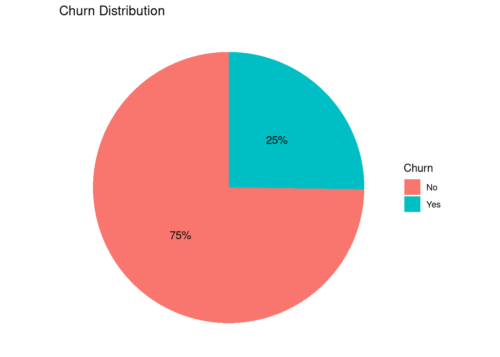

```r
# plotting a pie chart to investigate whether MTN customers churned

# prepare data
df <- Telecom_clean_df %>%
  group_by(churn) %>% # Variable to be transformed
  count() %>%
  ungroup() %>%
  mutate(perc = `n` / sum(`n`)) %>%
  arrange(perc) %>%
  mutate(labels = scales::percent(perc))

# df_1 <- Telecom_clean_df %>%
#   count(churn)
# df_1

#Plot
ggplot(df, aes(x = "", y = perc, fill = churn)) +
  geom_col() +
  geom_text(aes(label = labels),
            position = position_stack(vjust = 0.5)) +
  labs(
    fill = "Churn",
    title = "Churn Distribution"
  ) +
  coord_polar(theta = "y")+
  theme_void()
```

```r
# we investigate the distribution of churn by senior citizen
# and recording our observations.
df_snr <- Telecom_clean_df %>%
  filter(seniorcitizen =='Yes') %>%
  group_by(churn) %>% # Variable to be transformed
  count() %>%
  ungroup() %>%
  mutate(perc = `n` / sum(`n`)) %>%
  arrange(perc) %>%
  mutate(labels = scales::percent(perc))
df_snr
```

| churn | n | perc | labels |
| --- | --- | --- | --- |
| Yes | 384 | 0.4050633 | 41% |
| No | 564 | 0.5949367 | 59% |

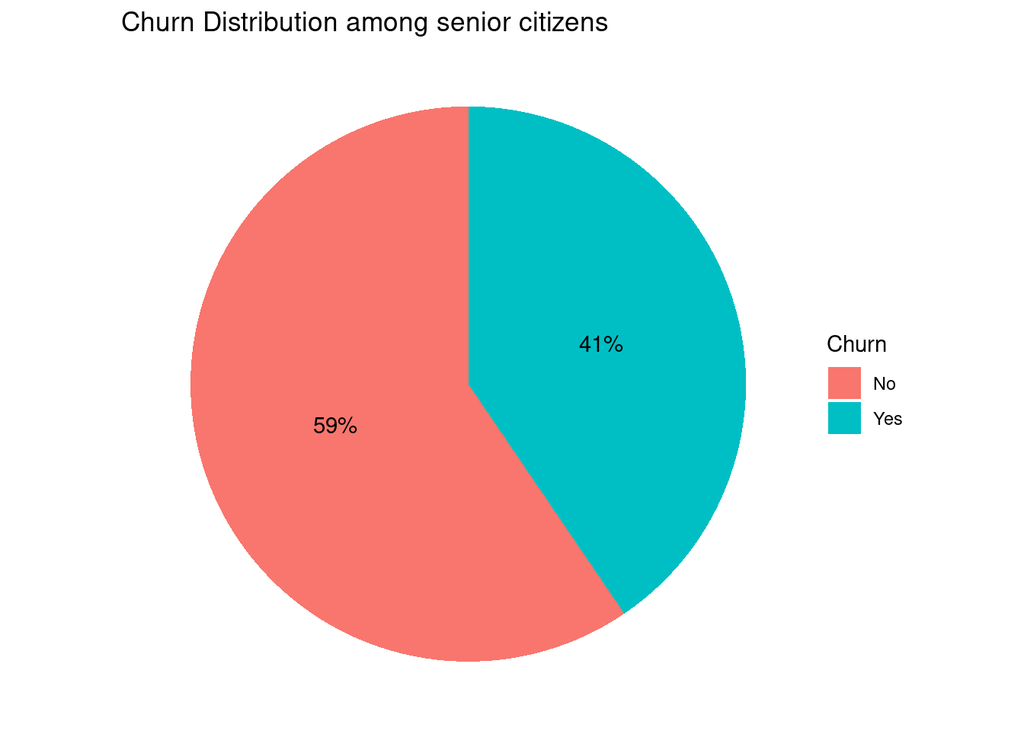

```r
#plot the pie chart
ggplot(df_snr, aes(x = "", y = perc, fill = churn)) +
  geom_col() +
  geom_text(aes(label = labels),
            position = position_stack(vjust = 0.5)) +
  labs(
    fill = "Churn",
    title = "Churn Distribution among senior citizens"
  ) +
  coord_polar(theta = "y")+
  theme_void()
```

```r
# plotting the distribution of churn by partner
# and recording our observations.

df_ptr <- Telecom_clean_df %>%
  filter(churn =='Yes') %>%
  group_by(partner) %>% # Variable to be transformed
  count() %>%
  ungroup() %>%
  mutate(perc = `n` / sum(`n`)) %>%
  arrange(perc) %>%
  mutate(labels = scales::percent(perc))
df_ptr
```

| partner | n | perc | labels |
| --- | --- | --- | --- |
| Yes | 571 | 0.4078571 | 41% |
| No | 829 | 0.5921429 | 59% |

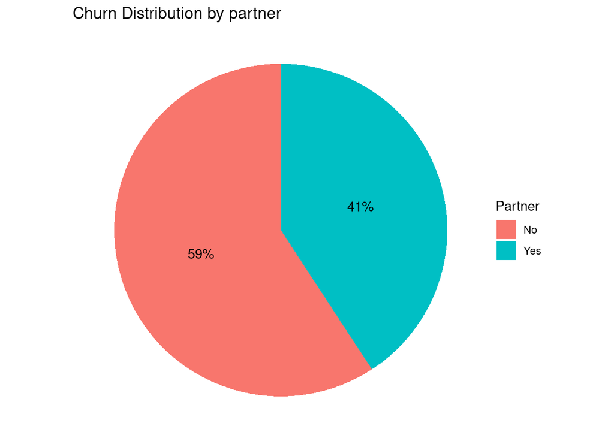

```r
#plot
ggplot(df_ptr, aes(x = "", y = perc, fill = partner)) +
  geom_col() +
  geom_text(aes(label = labels),
            position = position_stack(vjust = 0.5)) +
  labs(
    fill = "Partner",
    title = "Churn Distribution by partner"
  ) +
  coord_polar(theta = "y")+
  theme_void()
```

```r
# plotting the distribution of churn by dependents
# and then record your observations
df_dpt <- Telecom_clean_df %>%
  filter(churn =='Yes') %>%
  group_by(dependents) %>% # Variable to be transformed
  count() %>%
  ungroup() %>%
  mutate(perc = `n` / sum(`n`)) %>%
  arrange(perc) %>%
  mutate(labels = scales::percent(perc))
df_dpt
```

| dependents | n | perc | labels |
| --- | --- | --- | --- |
| Yes | 253 | 0.1807143 | 18% |
| No | 1147 | 0.8192857 | 82% |

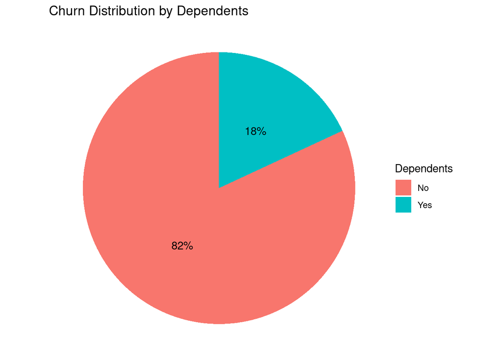

```r
#plot
ggplot(df_dpt, aes(x = "", y = perc, fill = dependents)) +
  geom_col() +
  geom_text(aes(label = labels),
            position = position_stack(vjust = 0.5)) +
  labs(
    fill = "Dependents",
    title = "Churn Distribution by Dependents"
  ) +
  coord_polar(theta = "y")+
  theme_void()
```

```r
# plotting the distribution of churn by phone service
# then recording your observations.

df_phn <- Telecom_clean_df %>%
  filter(churn =='Yes') %>%
  group_by(phoneservice) %>% # Variable to be transformed
  count() %>%
  ungroup() %>%
  mutate(perc = `n` / sum(`n`)) %>%
  arrange(perc) %>%
  mutate(labels = scales::percent(perc))
df_phn
```

| phoneservice | n | perc | labels |
| --- | --- | --- | --- |
| No | 113 | 0.08071429 | 8% |
| Yes | 1287 | 0.91928571 | 92% |

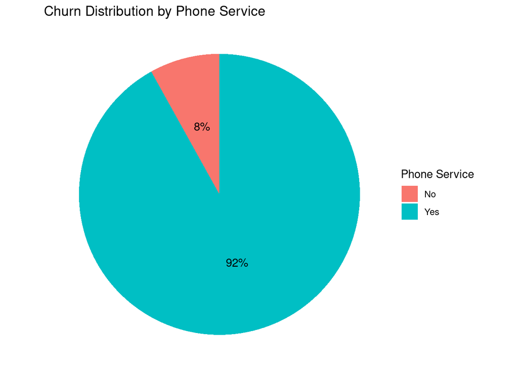

```r
#plot
ggplot(df_phn, aes(x = "", y = perc, fill = phoneservice)) +
  geom_col() +
  geom_text(aes(label = labels),
            position = position_stack(vjust = 0.5)) +
  labs(
    fill = "Phone Service",
    title = "Churn Distribution by Phone Service "
  ) +
  coord_polar(theta = "y")+
  theme_void()
```

```r
# plotting the distribution of churn by internet service
# and later record our observations.

df_int <- Telecom_clean_df %>%
  filter(churn =='Yes') %>%
  group_by(internetservice) %>% # Variable to be transformed
  count() %>%
  ungroup() %>%
  mutate(perc = `n` / sum(`n`)) %>%
  arrange(perc) %>%
  mutate(labels = scales::percent(perc))
df_int
```

| internetservice | n | perc | labels |
| --- | --- | --- | --- |
| No | 31 | 0.02214286 | 2% |
| DSL | 313 | 0.22357143 | 22% |
| Fiber optic | 1056 | 0.75428571 | 75% |

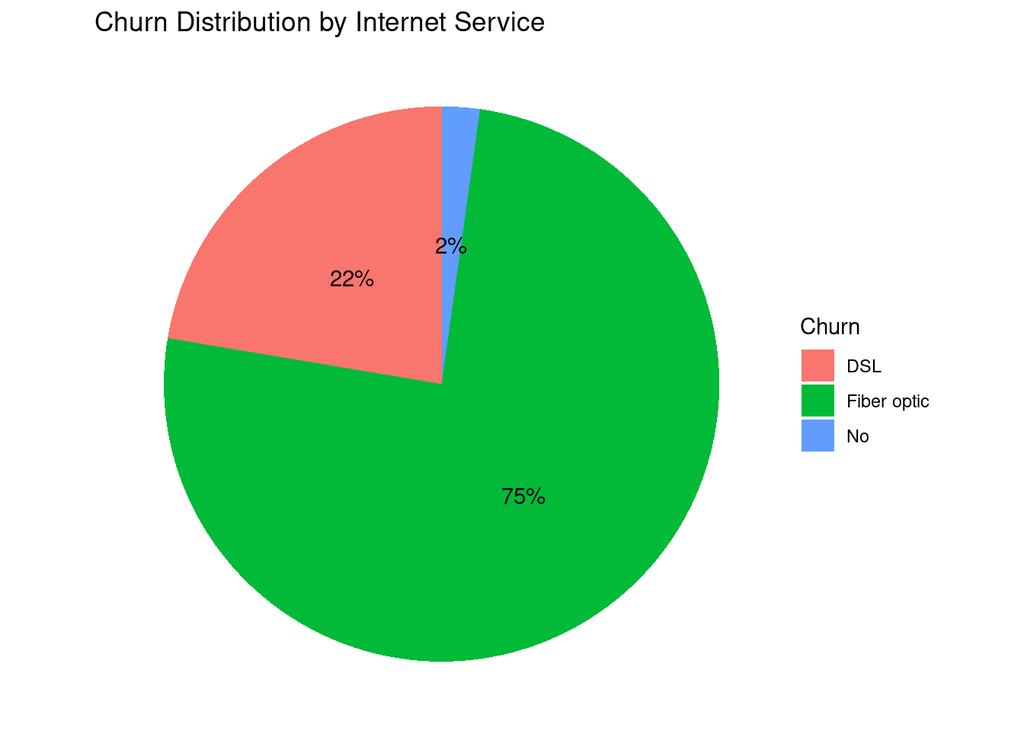

```r
#plot
ggplot(df_int, aes(x = "", y = perc, fill = internetservice)) +
  geom_col() +
  geom_text(aes(label = labels),
            position = position_stack(vjust = 0.5)) +
  labs(
    fill = "Churn",
    title = "Churn Distribution by Internet Service"
  ) +
  coord_polar(theta = "y")+
  theme_void()
```

```r
# plotting the distribution of churn by online security and then record
# our observations below:
df_sec <- Telecom_clean_df %>%
  filter(churn =='Yes') %>%
  group_by(onlinesecurity) %>% # Variable to be transformed
  count() %>%
  ungroup() %>%
  mutate(perc = `n` / sum(`n`)) %>%
  arrange(perc) %>%
  mutate(labels = scales::percent(perc))
df_sec
```

| onlinesecurity | n | perc | labels |
| --- | --- | --- | --- |
| No internet service | 31 | 0.02214286 | 2% |
| Yes | 254 | 0.18142857 | 18% |
| No | 1115 | 0.79642857 | 80% |

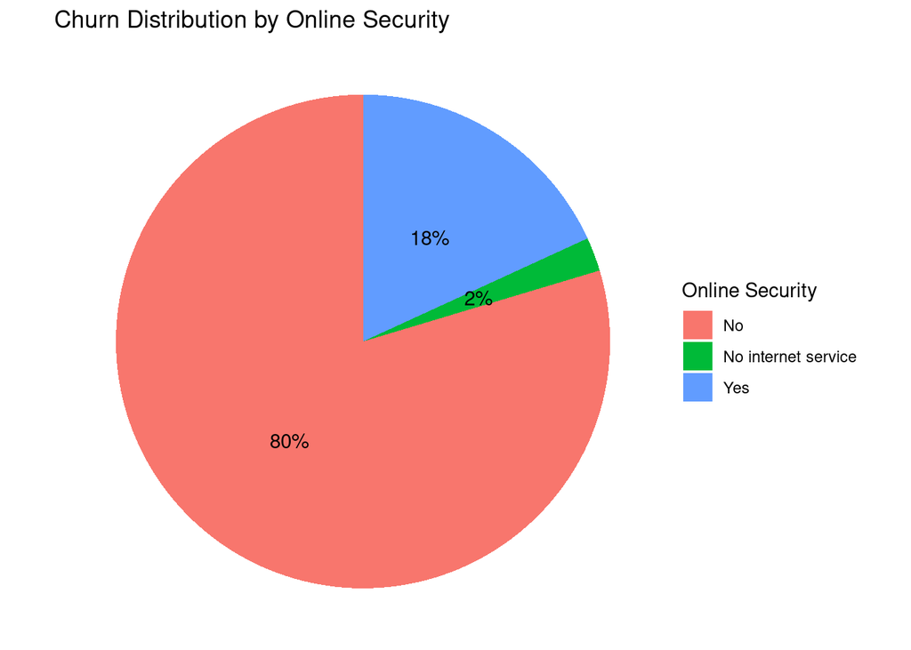

```r
#plot
ggplot(df_sec, aes(x = "", y = perc, fill = onlinesecurity)) +
  geom_col() +
  geom_text(aes(label = labels),
            position = position_stack(vjust = 0.5)) +
  labs(
    fill = "Online Security",
    title = "Churn Distribution by Online Security"
  ) +
  coord_polar(theta = "y")+
  theme_void()
```

```r
# plotting the distribution of churn by online backup
df_bckup <- Telecom_clean_df %>%
  filter(churn =='Yes') %>%
  group_by(onlinebackup) %>% # Variable to be transformed
  count() %>%
  ungroup() %>%
  mutate(perc = `n` / sum(`n`)) %>%
  arrange(perc) %>%
  mutate(labels = scales::percent(perc))
df_bckup
```

| onlinebackup | n | perc | labels |
| --- | --- | --- | --- |
| No internet service | 31 | 0.02214286 | 2% |
| Yes | 456 | 0.32571429 | 33% |
| No | 913 | 0.65214286 | 65% |

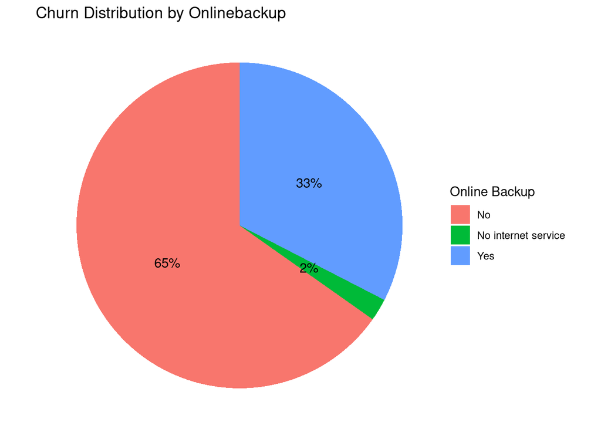

```r
#plot
ggplot(df_bckup, aes(x = "", y = perc, fill = onlinebackup)) +
  geom_col() +
  geom_text(aes(label = labels),
            position = position_stack(vjust = 0.5)) +
  labs(
    fill = "Online Backup",
    title = "Churn Distribution by Onlinebackup"
  ) +
  coord_polar(theta = "y")+
  theme_void()
```

```r
# plotting the distribution of churn by tech support
df_techspt <- Telecom_clean_df %>%
  filter(churn =='Yes') %>%
  group_by(techsupport) %>% # Variable to be transformed
  count() %>%
  ungroup() %>%
  mutate(perc = `n` / sum(`n`)) %>%
  arrange(perc) %>%
  mutate(labels = scales::percent(perc))
df_techspt
```

| techsupport | n | perc | labels |
| --- | --- | --- | --- |
| No internet service | 31 | 0.02214286 | 2% |
| Yes | 264 | 0.18857143 | 19% |
| No | 1105 | 0.78928571 | 79% |

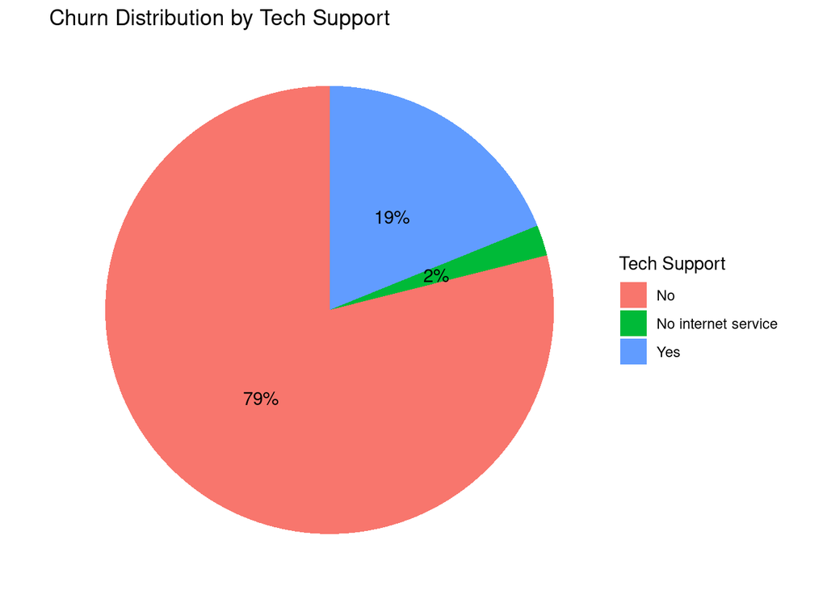

```r
#plot
ggplot(df_techspt, aes(x = "", y = perc, fill = techsupport)) +
  geom_col() +
  geom_text(aes(label = labels),
            position = position_stack(vjust = 0.5)) +
  labs(
    fill = "Tech Support",
    title = "Churn Distribution by Tech Support"
  ) +
  coord_polar(theta = "y")+
  theme_void()
```

```r
# plotting the distribution of churn by streaming tv

df_tv <- Telecom_clean_df %>%
  filter(churn =='Yes') %>%
  group_by(streamingtv) %>% # Variable to be transformed
  count() %>%
  ungroup() %>%
  mutate(perc = `n` / sum(`n`)) %>%
  arrange(perc) %>%
  mutate(labels = scales::percent(perc))
df_tv
```

| streamingtv | n | perc | labels |
| --- | --- | --- | --- |
| No internet service | 31 | 0.02214286 | 2.2% |
| No | 664 | 0.47428571 | 47.4% |
| Yes | 705 | 0.50357143 | 50.4% |

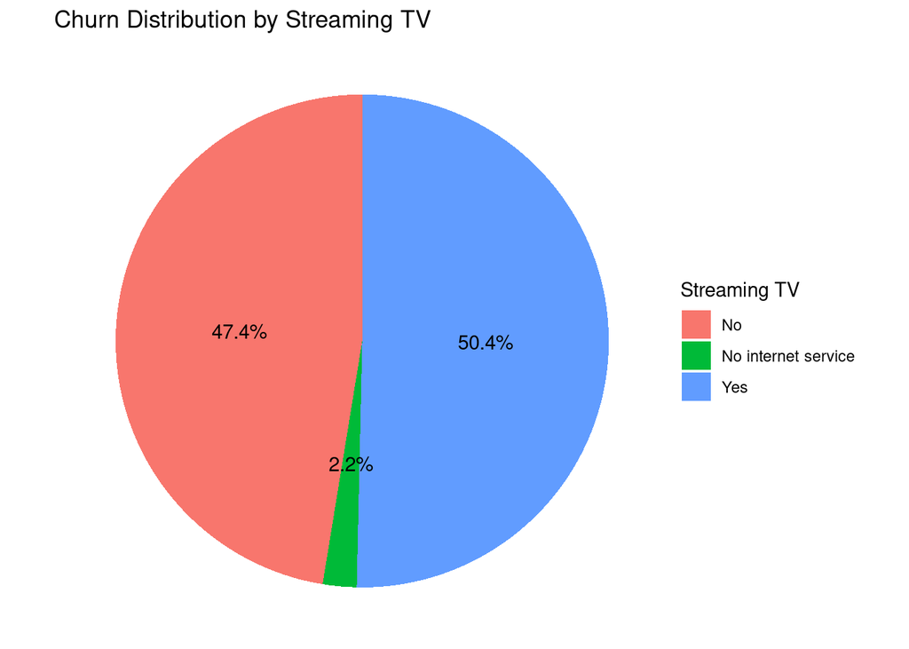

```r
#plot
ggplot(df_tv, aes(x = "", y = perc, fill = streamingtv)) +
  geom_col() +
  geom_text(aes(label = labels),
            position = position_stack(vjust = 0.5)) +
  labs(
    fill = "Streaming TV",
    title = "Churn Distribution by Streaming TV"
  ) +
  coord_polar(theta = "y")+
  theme_void()
```

```r
# plotting the distribution of churn by streaming movies
df_movies <- Telecom_clean_df %>%
  filter(churn =='Yes') %>%
  group_by(streamingmovies) %>% # Variable to be transformed
  count() %>%
  ungroup() %>%
  mutate(perc = `n` / sum(`n`)) %>%
  arrange(perc) %>%
  mutate(labels = scales::percent(perc))
df_movies
```

| streamingmovies | n | perc | labels |
| --- | --- | --- | --- |
| No internet service | 31 | 0.02214286 | 2.2% |
| No | 661 | 0.47214286 | 47.2% |
| Yes | 708 | 0.50571429 | 50.6% |

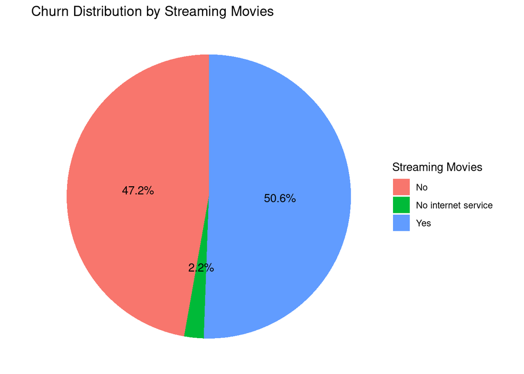

```r
#plot
ggplot(df_movies, aes(x = "", y = perc, fill = streamingmovies)) +
  geom_col() +
  geom_text(aes(label = labels),
            position = position_stack(vjust = 0.5)) +
  labs(
    fill = "Streaming Movies",
    title = "Churn Distribution by Streaming Movies"
  ) +
  coord_polar(theta = "y")+
  theme_void()
```

```r
# plotting the distribution of churn by contract
df_ctrct <- Telecom_clean_df %>%
  filter(churn =='Yes') %>%
  group_by(contract) %>% # Variable to be transformed
  count() %>%
  ungroup() %>%
  mutate(perc = `n` / sum(`n`)) %>%
  arrange(perc) %>%
  mutate(labels = scales::percent(perc))
df_ctrct
```

| contract | n | perc | labels |
| --- | --- | --- | --- |
| Two year | 36 | 0.02571429 | 2.6% |
| One year | 149 | 0.10642857 | 10.6% |
| Month-to-month | 1215 | 0.86785714 | 86.8% |

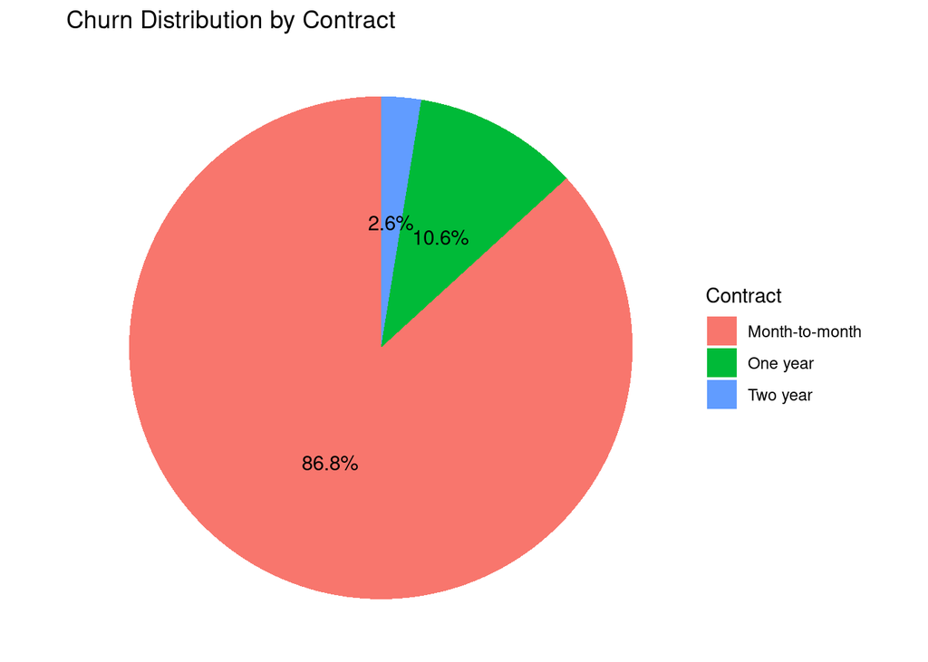

```r
#plot
ggplot(df_ctrct, aes(x = "", y = perc, fill = contract)) +
  geom_col() +
  geom_text(aes(label = labels),
            position = position_stack(vjust = 0.5)) +
  labs(
    fill = "Contract",
    title = "Churn Distribution by Contract"
  ) +
  coord_polar(theta = "y")+
  theme_void()
```

```r
# plotting the distribution of churn by paperless billing
df_ppr <- Telecom_clean_df %>%
  filter(churn =='Yes') %>%
  group_by(paperlessbilling) %>% # Variable to be transformed
  count() %>%
  ungroup() %>%
  mutate(perc = `n` / sum(`n`)) %>%
  arrange(perc) %>%
  mutate(labels = scales::percent(perc))
df_ppr
```

| paperlessbilling | n | perc | labels |
| --- | --- | --- | --- |
| No | 313 | 0.2235714 | 22% |
| Yes | 1087 | 0.7764286 | 78% |

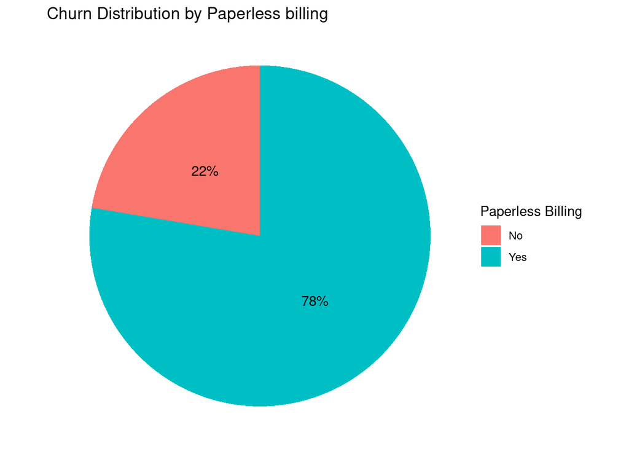

```r
#plot
ggplot(df_ppr, aes(x = "", y = perc, fill = paperlessbilling)) +
  geom_col() +
  geom_text(aes(label = labels),
            position = position_stack(vjust = 0.5)) +
  labs(
    fill = "Paperless Billing",
    title = "Churn Distribution by Paperless billing"
  ) +
  coord_polar(theta = "y")+
  theme_void()
```

```r
# plotting the distribution of churn by payment method

df_pay <- Telecom_clean_df %>%
  filter(churn =='Yes') %>%
  group_by(paymentmethod) %>% # Variable to be transformed
  count() %>%
  ungroup() %>%
  mutate(perc = `n` / sum(`n`)) %>%
  arrange(perc) %>%
  mutate(labels = scales::percent(perc))
df_pay
```

| paymentmethod | n | perc | labels |
| --- | --- | --- | --- |
| Mailed check | 157 | 0.1121429 | 11.2% |
| Credit card (automatic) | 207 | 0.1478571 | 14.8% |
| Bank transfer (automatic) | 225 | 0.1607143 | 16.1% |
| Electronic check | 811 | 0.5792857 | 57.9% |

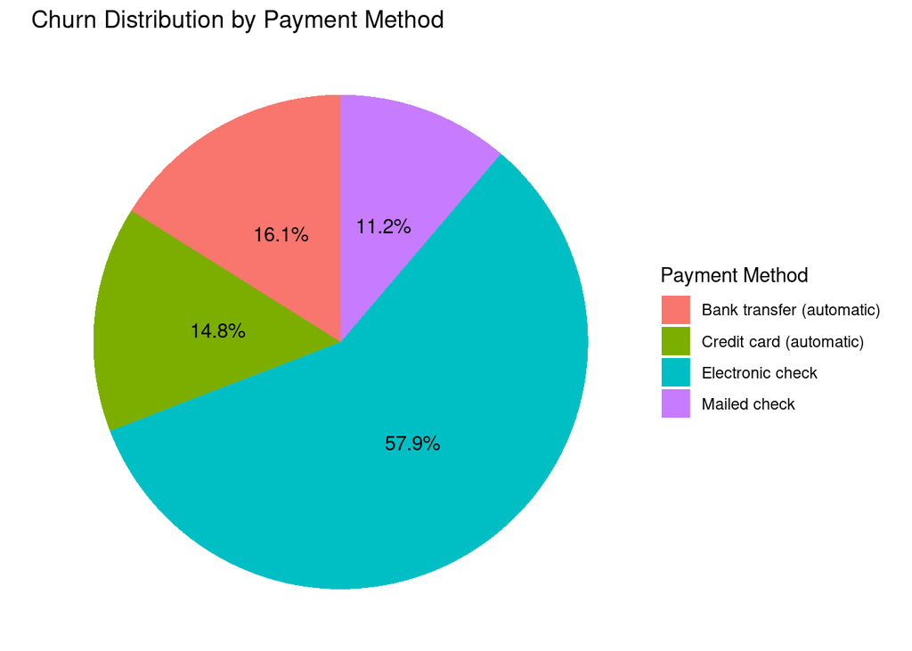

```r
#plot
ggplot(df_pay, aes(x = "", y = perc, fill = paymentmethod)) +
  geom_col() +
  geom_text(aes(label = labels),
            position = position_stack(vjust = 0.5)) +
  labs(
    fill = "Payment Method",
    title = "Churn Distribution by Payment Method"
  ) +
  coord_polar(theta = "y")+
  theme_void()
```